# IS608_HW2

Daina Bouquin

March 4, 2016

```r
library(dplyr)
library(ggplot2)
library(devtools)
devtools::install_github("hadley/bigvis")
library(bigvis)
library(RColorBrewer)
```

I have provided you with data about every tax lot in NYC, in a zip file. Please download it from [here](http://www.nyc.gov/html/dcp/html/bytes/dwn_pluto_mappluto.shtml). You will need to combine the data from each boro into one file called ‘all_PLUTO_data.R’ in order to complete this assignment.

```r
# The files are larger than the recommended file size for GitHub and are therefore accessed locally
bk <- read.csv('BK.csv', header=TRUE) # Brooklyn
bx <- read.csv('BX.csv', header=TRUE) # The Bronx
mn <- read.csv('Mn.csv', header=TRUE) # Manhattan
qn <- read.csv('QN.csv', header=TRUE) # Queens
si <- read.csv('SI.csv', header=TRUE) # Statan Island

# Merge datasets by row
all_pluto <- rbind(bk,bx,mn,qn,si)
table(all_pluto$BoroCode)
```

```
##
##      1      2      3      4      5
##  43230  89963 277748 324630 123892
```

```r
# Create a file containing all of the merged data
write.csv(all_pluto, "all_PLUTO_data.csv")
```

#### Questions:

1. After a few building collapses, the City of New York is going to begin investigating older buildings for safety. However, the city has a limited number of inspectors, and wants to find a ‘cut-off’ date before most city buildings were constructed. Build a graph to help the city determine **when most buildings were constructed**. Is there anything in the results that causes you to question the accuracy of the data? (note: only look at buildings built since 1850)

```r
# Read in the newly created CSV
all_pluto <- read.csv('all_PLUTO_data.csv')
# check out a summary of the dates
summary(all_pluto$YearBuilt)
```

```
##    Min. 1st Qu.  Median    Mean 3rd Qu.    Max.    NA's
##       0    1920    1930    1839    1955    2040       1
```

```r
# How many == zero?? When were these built? Also, 2040??
count(filter(all_pluto, YearBuilt== 0))
```

```
## Source: local data frame [1 x 1]
##
##       n
##   (int)
## 1 44979
```

```r
# nearly 45,000 with potentially unknown date. This makes me question the accuracy of the data
# there's also 1 building with a build date far in the future, which is strange.
count(filter(all_pluto, YearBuilt> 2016))
```

```
## Source: local data frame [1 x 1]
##
##       n
##   (int)
## 1     1
```

```r
# Remove strange dates as they will also impact the binning
sub_all_pluto <- subset(all_pluto, YearBuilt != 0)
sub_all_pluto <- subset(sub_all_pluto, YearBuilt <= 2016)
summary(sub_all_pluto$YearBuilt)
```

```
##    Min. 1st Qu.  Median    Mean 3rd Qu.    Max.
##    1661    1920    1931    1941    1958    2015
```

```r
# subset out the buildings built since 1850
post_1850 <- subset(sub_all_pluto, YearBuilt > 1850)
# use condense
c_post_1850 <- condense(bin(post_1850$YearBuilt, 10))

# Figure out when most were built
# "when most buildings were constructed" == more than half of them were built.
half_built <- sum(c_post_1850$.count)/2
half_built # count that must be surpassed
```

```
## [1] 407010
```

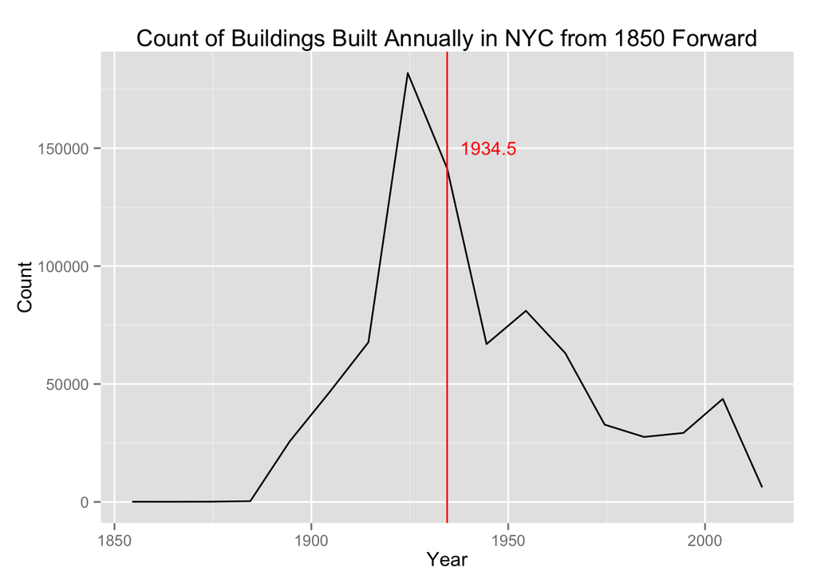

```r
# Create columm for cumulative sum
cs_post_1850 <- within(c_post_1850, cumulative_sum <- cumsum(.count))
# find years where more than half of the buildings had been built
half_built_years <- filter(cs_post_1850, cumulative_sum > half_built)
cut_off <- min(half_built_years[1]) # 1934.5 is the 'cut off'

# make a plot showing when most buildings were constructed
q1_a <- autoplot(c_post_1850) +
  labs(title="Buildings Built Annually Since 1850") +
  geom_vline(aes(xintercept = cut_off), colour="red") +
  annotate("text", x = 1945, y = 150000, label = cut_off, colour="red", size = 4) +
  labs(title="Count of Buildings Built Annually in NYC from 1850 Forward", x = "Year", y= "Count")

q1_a
```

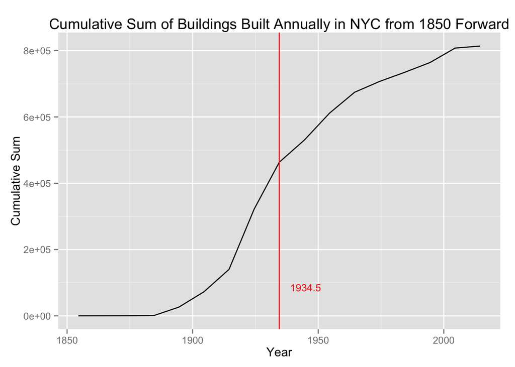

```r
ggsave("q1_a.png", width = 7.5, height=5.5)

# Compare the autoplot with a plot showing cumulative sum
q1_b <- ggplot(cs_post_1850, aes(x=post_1850.YearBuilt, y=cumulative_sum, group=1)) +
  geom_line() +
  geom_vline(aes(xintercept = cut_off), colour="red") +
  annotate("text", x = 1945, y = 85000, label = cut_off, colour="red", size =3.5) +
  labs(title="Cumulative Sum of Buildings Built Annually in NYC from 1850 Forward", x = "Year", y= "Cumulative Sum")

q1_b
```

```r
ggsave("q1_b.png", width = 7.5, height=5.5)
```

2. The city is particularly worried about buildings that were unusually tall when they were built, since best-practices for safety hadn’t yet been determined. Create a graph that shows how many buildings of a certain number of floors were built in each year (note: you may want to use a log scale for the number of buildings). It should be clear when 20-story buildings, 30-story buildings, and 40-story buildings were first built in large numbers.

```r
# aggregate counts by year and number of floors
year_floors <- plyr::count(post_1850, vars = c("NumFloors", "YearBuilt"))
# Add a column for rounded tens of stories
stories <- round(year_floors$NumFloors, -1)
year_floors <- cbind(year_floors, stories)
# Check out the structure of the date
head(year_floors[year_floors$NumFloors > 70,])
```

```
##      NumFloors YearBuilt freq stories
## 4069        75      2001    1      80
## 4070        76      2007    1      80
## 4071        77      2009    1      80
## 4072        78      1986    1      80
## 4073        82      1980    1      80
## 4074        85      1931    1      80
```

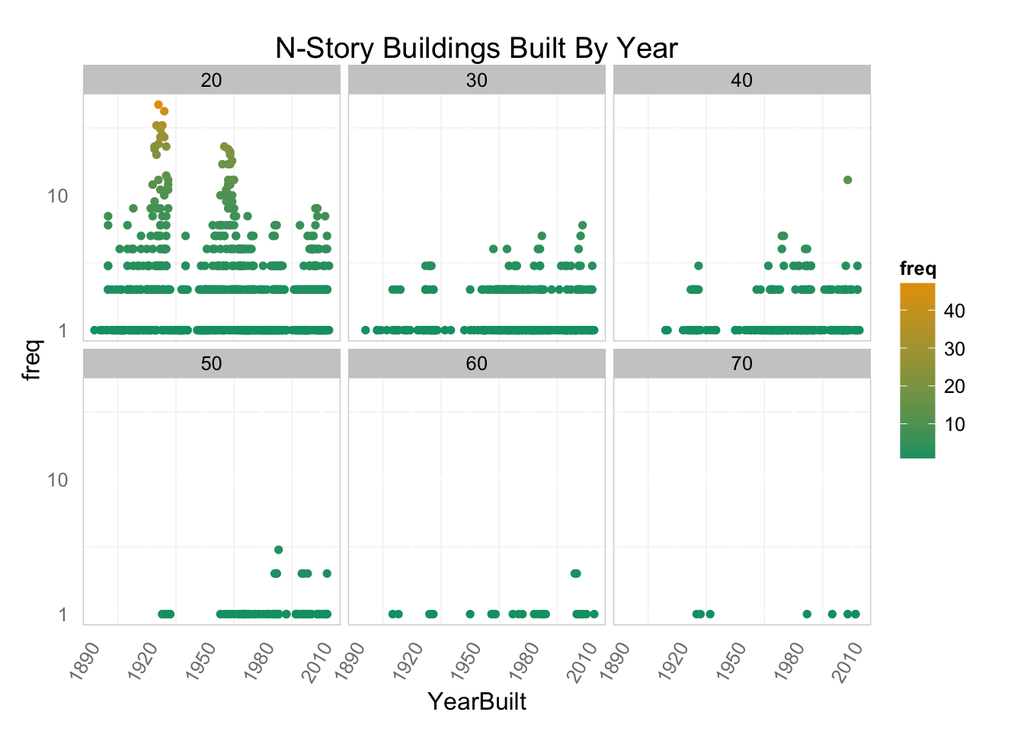

```r
# Subset- we only want tall buildings.
# 20-70 story buildings
tall <- year_floors[10 < year_floors$stories & year_floors$stories <= 70 & year_floors$freq > 0,]

# Create a plot with color-blind friendly tones
q2 <- ggplot(tall, aes(x=YearBuilt, y=freq, color=freq)) +
  geom_point() +
  scale_y_log10() +
  scale_color_continuous() +
  facet_wrap(~ stories) +
  labs(title="N-Story Buildings Built By Year") +
  scale_colour_gradient(high = "#E69F00", low = "#009E73") +
  theme(axis.ticks=element_blank(),
                 axis.text.x=element_text(angle=60,hjust=1),
                 panel.border = element_rect(color="light gray", fill=NA),
                 panel.background=element_rect(fill="#ffffff"),
                 panel.grid.major.y=element_line(color="white", size=0.5),
                 panel.grid.major.x=element_line(color="white", size=0.5))

q2
```

```r
ggsave("q2.png", width = 8, height=5.5)
```

3. Your boss suspects that buildings constructed during the US’s involvement in World War II (1941-1945) are more poorly constructed than those before and after the way due to the high cost of materials during those years. She thinks that, if you calculate assessed value per floor, you will see lower values for buildings at that time vs before or after. Construct a chart/graph to see if she’s right.

```r
# Assessed value per floor around WWII.
# Subset out data from WWII +/- 5 years
WWIIish <- subset(all_pluto, 1936 < all_pluto$YearBuilt & all_pluto$YearBuilt < 1950 & all_pluto$NumFloors > 0)

# Calculate the assessed value per floor without factoring in AssessLand -- this may have nothing to do with building materials
value_floor <- (WWIIish$AssessTot - WWIIish$AssessLand)/ WWIIish$NumFloors
WWIIish <- cbind(WWIIish, value_floor)
head(WWIIish$value_floor)
```

```
## [1] 615825  67950  46440  99000 508950 105525
```

```r
# Get the median value per floor by year. May be more appropriate than mean.
med_value_floor_year <- plyr::ddply(WWIIish, "YearBuilt", plyr::summarise, med_value_floor = median(value_floor))

# Repeat this process for the 10 years prior to and 10 years after the WWII-ish years
# Prior to WWII years
pre_WWII <- subset(all_pluto, 1926 < all_pluto$YearBuilt & all_pluto$YearBuilt < 1937 & all_pluto$NumFloors > 0)
# value by floor
value_floor2 <- (pre_WWII$AssessTot - pre_WWII$AssessLand)/ pre_WWII$NumFloors
pre_WWII <- cbind(pre_WWII, value_floor2)
head(pre_WWII$value_floor)
```

```
## [1]  70312.5 713314.3 338935.3   6553.5   4950.0   2310.0
```

```r
# median value per floor by year.
med_value_floor_year2 <- plyr::ddply(pre_WWII, "YearBuilt", plyr::summarise, med_value_floor2 = median(value_floor2))

# After WWII years
post_WWII <- subset(all_pluto, 1949 < all_pluto$YearBuilt & all_pluto$YearBuilt < 1960 & all_pluto$NumFloors > 0)
# value by floor
value_floor3 <- (post_WWII$AssessTot - post_WWII$AssessLand)/ post_WWII$NumFloors
post_WWII <- cbind(post_WWII, value_floor3)
head(post_WWII$value_floor)
```

```
## [1]  74700.00 402750.00 252000.00 219600.00 296100.00  43539.33
```

```r
# median value per floor by year.
med_value_floor_year3 <- plyr::ddply(post_WWII, "YearBuilt", plyr::summarise, med_value_floor3 = median(value_floor3))

# Bind the data together by row
colnames(med_value_floor_year) <- c("YearBuilt", "med_value_floor")
colnames(med_value_floor_year2) <- c("YearBuilt", "med_value_floor")
colnames(med_value_floor_year3) <- c("YearBuilt", "med_value_floor")
value_data <- rbind(med_value_floor_year2, med_value_floor_year, med_value_floor_year3)

# add another column for categories
value_data$Era <- c(rep("Pre-WWII",10),rep("Around WWII", 13), rep("Post-WWII",10))

# clean up for plotting
value_data$YearBuilt <- as.factor(value_data$YearBuilt)
value_data$med_value_floor <- round(value_data$med_value_floor,2)

str(value_data)
```

```
## 'data.frame':    33 obs. of  3 variables:
##  $ YearBuilt      : Factor w/ 33 levels "1927","1928",..: 1 2 3 4 5 6 7 8 9 10 ...
##  $ med_value_floor: num  55650 37977 69771 7480 22002 ...
##  $ Era            : chr  "Pre-WWII" "Pre-WWII" "Pre-WWII" "Pre-WWII" ...
```

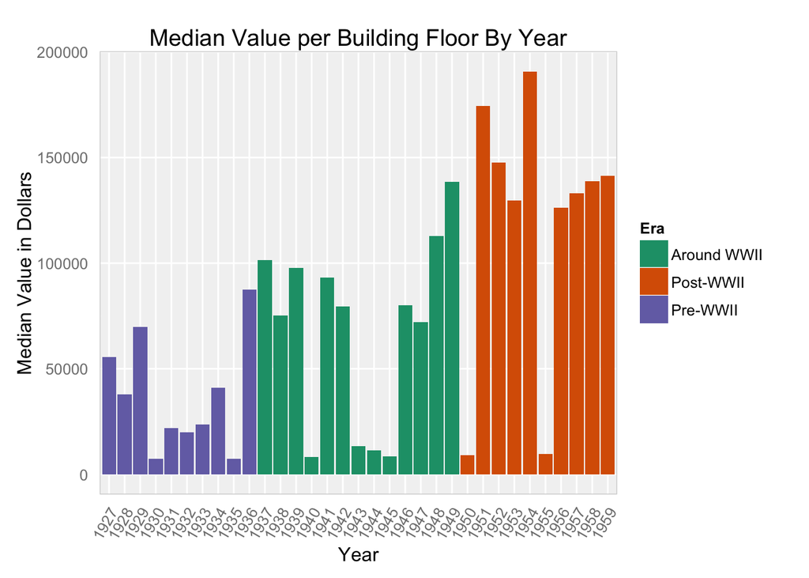

```r
q3 <- ggplot(value_data, aes(x=YearBuilt, y=med_value_floor, fill=Era)) +
  geom_bar(stat="identity") +
  scale_fill_brewer(palette = "Dark2") +
  labs(title="Median Value per Building Floor By Year", x= "Year", y= "Median Value in Dollars") +
  theme(axis.ticks=element_blank(),
                 axis.text.x=element_text(angle=60,hjust=1),
                 panel.border = element_rect(color="light gray", fill=NA),
                 panel.background=element_rect(fill="gray95"),
                 panel.grid.major.y=element_line(color="white", size=0.5),
                 panel.grid.major.x=element_line(color="white", size=0.5))
q3
```

```r
ggsave("q3.png", width = 8, height=5.5)
```

There doesn’t seem to be an obvious lower value per floor for buildings built in the 13 years surrounding WWII, there does though seem to be generally lower medial value per floor for building built around WWII and the depression.